# Como a distorção idade-série e o abandono escolar afetam a taxa de aprovação

# 📊 Análise acerca da realação entre distorção idade-série e o abandono escolar e sua relação com o afetam a taxa de aprovação

Carlos Eduardo Ribeiro

2025-11-01

## Introdução

### Introdução

A educação brasileira carrega, ao longo de décadas, desafios estruturais que impactam diretamente o futuro de milhões de estudantes. Entre esses desafios, dois se destacam pela intensidade com que afetam a trajetória escolar: a distorção idade-série — quando o estudante está em uma série incompatível com sua idade — e o abandono escolar, fenômeno que interrompe o direito à educação e compromete oportunidades futuras.

Ambos os indicadores se conectam profundamente à desigualdade social, ao acesso desigual a políticas públicas e às condições socioeconômicas regionais. Em muitos contextos, a repetência e o atraso escolar funcionam como um ciclo que se retroalimenta: estudantes mais velhos, deslocados do grupo etário, tendem a apresentar menor engajamento, maior exposição a riscos e maior probabilidade de abandonar a escola.

Neste trabalho, busco compreender como esses dois fenômenos — distorção idade-série e abandono escolar — influenciam a taxa de aprovação no Brasil, utilizando dados oficiais do INEP entre 2022 e 2024. Por meio de análise estatística e visualização de dados, investigamos padrões, relações e possíveis implicações para o sistema educacional brasileiro.

Meu objetivo não é apenas descrever números, mas gerar reflexão sobre os fatores que moldam a permanência e o sucesso dos estudantes. Ao entender como essas variáveis se relacionam, contribuímos para uma discussão essencial: como garantir que mais alunos avancem em suas trajetórias escolares com dignidade e qualidade?

### Definição do problema e Justificativa sociopedagógica

A reprovação e o abandono escolar continuam sendo indicadores críticos na educação básica brasileira. Entretanto, esses fenômenos não acontecem de forma isolada. Diversos estudos apontam que eles estão profundamente associados à distorção idade-série, situação em que o estudante acumula atrasos sucessivos que prejudicam seu aprendizado, sua motivação e seu vínculo com a escola.

O problema central que investigamos é:

Em que medida a distorção idade-série e o abandono escolar explicam a variação nas taxas de aprovação?

Justifica-se esta análise porque:

- A distorção idade-série funciona como um marcador de desigualdade educacional.
- O abandono escolar está associado a vulnerabilidades sociais e impactos econômicos.
- A aprovação escolar é um dos principais indicadores de progressão e sucesso educacional.
- Entender as relações entre esses indicadores auxilia gestores, pesquisadores e escolas na criação de políticas mais eficientes.

Além disso, o período analisado (2022–2024) é particularmente relevante, pois marca a fase de recuperação pós-pandemia, quando o país enfrentou picos de defasagem de aprendizagem e aumento nas desigualdades regionais.

### Abordagem, metodologia e utilidade da análise

A análise proposta parte da seguinte declaração de problema: entender como a distorção idade-série e o abandono escolar influenciam a taxa de aprovação no Brasil. Para abordar essa questão, utilizo os microdados oficiais do INEP referentes aos indicadores educacionais de 2022 a 2024, incluindo informações desagregadas por dependência administrativa, localização geográfica e etapas de ensino. Esses dados foram previamente tratados, padronizados e consolidados em uma base unificada, garantindo consistência, comparabilidade e ausência de duplicidades.

Ao adotar essa técnica, minha intenção é fornecer um diagnóstico claro que ajuda a responder total ou parcialmente o problema proposto. Embora a correlação não determine causalidade, ela revela padrões consistentes que sugerem onde políticas públicas ou ações de gestão podem ser mais efetivas. A combinação de estatísticas descritivas e correlações permite mapear fragilidades do sistema educacional e identificar grupos mais vulneráveis a reprovação e abandono.

Essa análise também tem utilidade prática para potenciais “clientes” — como gestores escolares, secretarias de educação, pesquisadores e formuladores de políticas públicas. Os resultados ajudam a:

- identificar fatores que mais pressionam a taxa de aprovação;
- priorizar regiões, redes ou etapas de ensino que exigem intervenção imediata;
- compreender como distorção e abandono caminham juntos e afetam o desempenho;
- embasar decisões com evidências, evitando achismos;
- orientar alocação de recursos, formação docente e políticas de permanência.

Com isso, a análise não apenas descreve o cenário educacional brasileiro, mas contribui para a formulação de estratégias mais eficientes, voltadas à redução da desigualdade e à melhoria da qualidade da educação.

## Pacotes utilizados

### Descrição utilizados

Todos os pacotes necessários para a análise foram carregados antecipadamente com o objetivo de garantir transparência, reprodutibilidade e facilidade de replicação dos resultados. Ao explicitar previamente as dependências do projeto, qualquer leitor, avaliador ou pesquisador pode instalar as mesmas bibliotecas e reproduzir o processamento de dados e as análises estatísticas sem inconsistências ou incompatibilidades.

## Baixando a Base de dados teste

```r
rm(list=ls())
```

## Tratando os dados

```r
limpar_inep_rendimento <- function(arquivo) {

  # Ler arquivo pulando cabeçalhos decorativos
  df <- read_excel(arquivo, skip = 9, col_names = FALSE)

  # Criar nomes das colunas conforme estrutura oficial
  nomes <- c(
    "ano", "unidade_geografica", "localizacao", "dependencia_administrativa",

    # Aprovação EF
    paste0("aprov_fund_", c(
      "total", "anos_iniciais", "anos_finais",
      "1ano","2ano","3ano","4ano","5ano","6ano","7ano","8ano","9ano"
    )),

    # Aprovação EM
    paste0("aprov_med_", c("total","1serie","2serie","3serie","4serie","nao_seriado")),

    # Reprovação EF
    paste0("reprov_fund_", c(
      "total", "anos_iniciais", "anos_finais",
      "1ano","2ano","3ano","4ano","5ano","6ano","7ano","8ano","9ano"
    )),

    # Reprovação EM
    paste0("reprov_med_", c("total","1serie","2serie","3serie","4serie","nao_seriado")),

    # Abandono EF
    paste0("aband_fund_", c(
      "total", "anos_iniciais", "anos_finais",
      "1ano","2ano","3ano","4ano","5ano","6ano","7ano","8ano","9ano"
    )),

    # Abandono EM
    paste0("aband_med_", c("total","1serie","2serie","3serie","4serie","nao_seriado"))
  )

  # Aplicar nomes
  colnames(df) <- nomes

  # Tratamento de dados
  df <- df %>%
    mutate(across(where(is.character), ~ gsub(",", ".", .))) %>%  # vírgula → ponto
    mutate(across(everything(), ~ na_if(., "--"))) %>%            # "--" → NA
    mutate(across(everything(), ~ na_if(., ""))) %>%              # "" → NA
    mutate(across(-c(ano, unidade_geografica, localizacao, dependencia_administrativa),
                  ~ suppressWarnings(as.numeric(.))))              # converter números

  return(df)
}
```

```r
limpar_inep_distorcao <- function(arquivo) {

  df <- read_excel(arquivo, skip = 9, col_names = FALSE)

  nomes <- c(
    "ano", "unidade_geografica", "localizacao", "dependencia_administrativa",

    # TDI – Ensino Fundamental
    paste0("tdi_fund_", c(
      "total","anos_iniciais","anos_finais",
      "1ano","2ano","3ano","4ano","5ano",
      "6ano","7ano","8ano","9ano"
    )),

    # TDI – Ensino Médio
    paste0("tdi_med_", c("total","1serie","2serie","3serie","4serie"))
  )

  colnames(df) <- nomes

  df <- df %>%
    mutate(across(where(is.character), ~ gsub(",", ".", .))) %>%
    mutate(across(everything(), ~ na_if(., "--"))) %>%
    mutate(across(everything(), ~ na_if(., ""))) %>%
    mutate(across(-c(ano, unidade_geografica, localizacao, dependencia_administrativa),
                  ~ suppressWarnings(as.numeric(.))))

  return(df)
}
```

```r
library(readxl)
library(dplyr)
library(purrr)
library(janitor)
```

```r
caminho <- "C:/Users/carlo/Downloads/data"

arquivos <- list(
  rendimento_2022 = file.path(caminho, "tx_rend_brasil_regioes_ufs_2022.xlsx"),
  rendimento_2023 = file.path(caminho, "tx_rend_brasil_regioes_ufs_2023.xlsx"),
  rendimento_2024 = file.path(caminho, "tx_rend_brasil_regioes_ufs_2024.xlsx"),

  distorcao_2022 = file.path(caminho, "TDI_BRASIL_REGIOES_UFS_2022.xlsx"),
  distorcao_2023 = file.path(caminho, "TDI_BRASIL_REGIOES_UFS_2023.xlsx"),
  distorcao_2024 = file.path(caminho, "TDI_BRASIL_REGIOES_UFS_2024.xlsx")
)

dados <- map(arquivos, ~ read_excel(.x) %>% clean_names())
names(dados) <- names(arquivos)
```

```r
dados <- map2(
  names(arquivos),
  arquivos,
  function(nm, arq) {
    if (grepl("rendimento", nm)) {
      limpar_inep_rendimento(arq)
    } else {
      limpar_inep_distorcao(arq)
    }
  }
) %>% set_names(names(arquivos))
# Rendimento (2022–2024)
rendimento <- bind_rows(
  dados$rendimento_2022 %>% mutate(ano = 2022),
  dados$rendimento_2023 %>% mutate(ano = 2023),
  dados$rendimento_2024 %>% mutate(ano = 2024)
)

# Distorção idade-série
distorcao <- bind_rows(
  dados$distorcao_2022 %>% mutate(ano = 2022),
  dados$distorcao_2023 %>% mutate(ano = 2023),
  dados$distorcao_2024 %>% mutate(ano = 2024)
)
```

```r
# --- 1. Unir os datasets já tratados ---
rendimento$origem <- "rendimento"
distorcao$origem <- "distorcao"

# Garantir que ano, localização, unidade, dependência existam em ambos
chaves <- c("ano","unidade_geografica","localizacao","dependencia_administrativa")

# Selecionar só variáveis importantes
rend_key <- rendimento %>% select(any_of(chaves),
                                  starts_with("aprov"),
                                  starts_with("reprov"),
                                  starts_with("aband"))

dist_key <- distorcao %>% select(any_of(chaves),
                                  starts_with("tdi"))

# --- 2. Juntar (inner_join garante alinhamento perfeito entre bases) ---
base_final <- rend_key %>%
  inner_join(dist_key, by = chaves)
glimpse(base_final)
```

```
## Rows: 1,772
## Columns: 75
## $ ano                        <dbl> 2022, 2022, 2022, 2022, 2022, 2022, 2022, 2…
## $ unidade_geografica         <chr> "Brasil", "Brasil", "Brasil", "Brasil", "Br…
## $ localizacao                <chr> "Total", "Urbana", "Rural", "Total", "Urban…
## $ dependencia_administrativa <chr> "Total", "Total", "Total", "Federal", "Fede…
## $ aprov_fund_total           <dbl> 94.2, 94.7, 90.8, 96.1, 96.0, 98.6, 93.8, 9…
## $ aprov_fund_anos_iniciais   <dbl> 96.0, 96.5, 93.1, 97.5, 97.5, 97.5, 96.9, 9…
## $ aprov_fund_anos_finais     <dbl> 92.1, 92.7, 87.5, 95.5, 95.4, 100.0, 92.7, …
## $ aprov_fund_1ano            <dbl> 98.7, 98.7, 98.5, 98.4, 98.4, 100.0, 98.9, …
## $ aprov_fund_2ano            <dbl> 97.8, 97.9, 97.5, 97.5, 97.4, 100.0, 98.4, …
## $ aprov_fund_3ano            <dbl> 94.2, 94.7, 91.4, 95.6, 95.7, 85.7, 95.3, 9…
## $ aprov_fund_4ano            <dbl> 95.0, 95.7, 91.0, 97.9, 97.9, 100.0, 97.3, …
## $ aprov_fund_5ano            <dbl> 94.2, 95.3, 87.8, 97.9, 97.9, 100.0, 95.2, …
## $ aprov_fund_6ano            <dbl> 92.4, 93.3, 86.3, 96.5, 96.5, 100.0, 94.3, …
```

[output cut: 62 more lines]

```r
base_final <- base_final %>%
  mutate(
    # Indicadores combinados
    distorcao_total = rowMeans(select(., tdi_fund_total, tdi_med_total), na.rm = TRUE),
    abandono_total  = rowMeans(select(., aband_fund_total, aband_med_total), na.rm = TRUE),
    aprovacao_total = rowMeans(select(., aprov_fund_total, aprov_med_total), na.rm = TRUE)
  )
```

```r
limpar_inep_rendimento <- function(arquivo) {

  # Agora pulando exatamente as 8 linhas corretas
  df <- read_excel(arquivo, skip = 8, col_names = TRUE)

  # Limpa nomes automáticos
  df <- clean_names(df)

  # Troca vírgulas por pontos apenas onde necessário
  df <- df %>%
    mutate(across(where(is.character), ~ gsub(",", ".", .)))

  # Converte as colunas numéricas (mantendo 4 primeiras como texto)
  df <- df %>%
    mutate(across(
      -c(1:4),
      ~ suppressWarnings(as.numeric(.))
    ))

  return(df)
}

limpar_inep_distorcao <- function(arquivo) {

  df <- read_excel(arquivo, skip = 8, col_names = TRUE)

  df <- clean_names(df)

  df <- df %>%
    mutate(across(where(is.character), ~ gsub(",", ".", .)))

  df <- df %>%
    mutate(across(
      -c(1:4),
      ~ suppressWarnings(as.numeric(.))
    ))

  return(df)
}
```

## Análise de correlações

```r
library(dplyr)

correlacoes <- base_final %>%
  select(aprovacao_total, distorcao_total, abandono_total)

as.data.frame(cor(correlacoes, use = "complete.obs"))
```

|  | aprovacao_total | distorcao_total | abandono_total |
| --- | --- | --- | --- |
| aprovacao_total | 1.0000000 | -0.6769207 | -0.7945630 |
| distorcao_total | -0.6769207 | 1.0000000 | 0.7051748 |
| abandono_total | -0.7945630 | 0.7051748 | 1.0000000 |

## 🧪 Metodologia

A metodologia adotada na análise inclui:

1. readxl
- Permite importar arquivos Excel (.xlsx) diretamente para o R.
- Fundamental porque os indicadores educacionais do INEP são fornecidos exatamente nesse formato.
2. dplyr
- Pacote central para manipulação e transformação de dados.
- Usado para selecionar colunas, filtrar linhas, criar novas variáveis, agrupar dados e sumarizar resultados.
3. tidyr
- Auxilia na organização dos dados, especialmente em tarefas de pivotar colunas, normalizar estruturas e tratar bases “largas” ou “longas”.
4. stringr
- Conjunto de funções para manipulação de texto (strings).
- Essencial para ajustar nomes de variáveis, extrair anos dos nomes de arquivos e padronizar categorias.
5. purrr
- Facilita operações repetidas com listas e funções, como aplicar automaticamente funções de limpeza em vários arquivos do INEP.
6. janitor
- padronizar nomes das colunas (clean_names()),
- remover linhas vazias ou duplicadas,
- facilitar inspeções iniciais da base.
7. ggplot2
- Principal biblioteca de visualização de dados no R.
- Utilizado para gerar gráficos de correlação, dispersão e tendências temporais.

## Fonte dos Dados

### Fonte Principal

Todos os dados utilizados neste projeto estão disponíveis publicamente no portal do INEP, na área de dados abertos.

Link para fonte dos dados: [INEP – Indicadores Educacionais](https://www.gov.br/inep/pt-br/acesso-a-informacao/dados-abertos/indicadores-educacionais)

### Descrição e Preparação dos Dados

Os dados utilizados neste projeto foram obtidos no portal de Dados Abertos do Instituto Nacional de Estudos e Pesquisas Educacionais Anísio Teixeira (INEP), que publica anualmente indicadores oficiais da Educação Básica. O propósito original dessas bases é monitorar o desempenho e condições do fluxo escolar, permitindo que gestores, pesquisadores e o público geral acompanhem:

- Taxas de aprovação, reprovação e abandono escolar
- Indicadores de distorção idade-série
- Resultados desagregados por ano, unidade da federação, localização (urbana/rural) e dependência administrativa (Federal, Estadual, Municipal)

As bases utilizadas correspondem aos anos 2022, 2023 e 2024, sendo disponibilizadas pelo INEP já em formato de planilha Excel (.xlsx). Cada arquivo contém múltiplas seções e cabeçalhos extensos, pois foram originalmente organizados para leitura humana, não para análise automática. Assim, foi necessário um processo consistente de limpeza.

Os dados originais possuíam:

- Várias linhas de cabeçalho decorativo (identificação do INEP, título da tabela, explicações metodológicas).
- Ausência de nomes claros para as colunas, exigindo criação manual.
- Uso de vírgula no padrão brasileiro (“95,3”), necessitando conversão para ponto decimal.
- Valores ausentes representados por “–”, células vazias ou zeros artificiais, dependendo do indicador.

Essas características tornam essas bases típicas de dados governamentais brutos: completos, porém não imediatamente adequados para análise computacional.

## Tratando os dados

### Função limpar_inep_rendimento

```r
limpar_inep_rendimento <- function(arquivo) {

  # Ler arquivo pulando cabeçalhos decorativos
  df <- read_excel(arquivo, skip = 9, col_names = FALSE)

  # Criar nomes das colunas conforme estrutura oficial
  nomes <- c(
    "ano", "unidade_geografica", "localizacao", "dependencia_administrativa",

    # Aprovação EF
    paste0("aprov_fund_", c(
      "total", "anos_iniciais", "anos_finais",
      "1ano","2ano","3ano","4ano","5ano","6ano","7ano","8ano","9ano"
    )),

    # Aprovação EM
    paste0("aprov_med_", c("total","1serie","2serie","3serie","4serie","nao_seriado")),

    # Reprovação EF
    paste0("reprov_fund_", c(
      "total", "anos_iniciais", "anos_finais",
      "1ano","2ano","3ano","4ano","5ano","6ano","7ano","8ano","9ano"
    )),

    # Reprovação EM
    paste0("reprov_med_", c("total","1serie","2serie","3serie","4serie","nao_seriado")),

    # Abandono EF
    paste0("aband_fund_", c(
      "total", "anos_iniciais", "anos_finais",
      "1ano","2ano","3ano","4ano","5ano","6ano","7ano","8ano","9ano"
    )),

    # Abandono EM
    paste0("aband_med_", c("total","1serie","2serie","3serie","4serie","nao_seriado"))
  )

  # Aplicar nomes
  colnames(df) <- nomes

  # Tratamento de dados
  df <- df %>%
    mutate(across(where(is.character), ~ gsub(",", ".", .))) %>%  # vírgula → ponto
    mutate(across(everything(), ~ na_if(., "--"))) %>%            # "--" → NA
    mutate(across(everything(), ~ na_if(., ""))) %>%              # "" → NA
    mutate(across(-c(ano, unidade_geografica, localizacao, dependencia_administrativa),
                  ~ suppressWarnings(as.numeric(.))))              # converter números

  return(df)
}
```

Esta função realiza o tratamento das planilhas de rendimento do INEP, que possuem várias linhas de cabeçalhos decorativos e valores inconsistentes. Primeiro ignoramos as linhas iniciais e aplicamos nomes padronizados às colunas, garantindo que cada indicador (aprovação, reprovação e abandono por série e nível de ensino) seja identificado corretamente. Em seguida, substituímos vírgulas por pontos, convertemos valores inválidos (“–”, strings vazias) em NA e transformamos as colunas numéricas para permitir análises estatísticas confiáveis.

### Após a Função limpar_inep_distorcao

```r
limpar_inep_distorcao <- function(arquivo) {

  df <- read_excel(arquivo, skip = 9, col_names = FALSE)

  nomes <- c(
    "ano", "unidade_geografica", "localizacao", "dependencia_administrativa",

    # TDI – Ensino Fundamental
    paste0("tdi_fund_", c(
      "total","anos_iniciais","anos_finais",
      "1ano","2ano","3ano","4ano","5ano",
      "6ano","7ano","8ano","9ano"
    )),

    # TDI – Ensino Médio
    paste0("tdi_med_", c("total","1serie","2serie","3serie","4serie"))
  )

  colnames(df) <- nomes

  df <- df %>%
    mutate(across(where(is.character), ~ gsub(",", ".", .))) %>%
    mutate(across(everything(), ~ na_if(., "--"))) %>%
    mutate(across(everything(), ~ na_if(., ""))) %>%
    mutate(across(-c(ano, unidade_geografica, localizacao, dependencia_administrativa),
                  ~ suppressWarnings(as.numeric(.))))

  return(df)
}
```

Esta função segue a mesma lógica da anterior, mas aplicada às planilhas de distorção idade-série. Após ignorar os cabeçalhos decorativos, atribuímos nomes coerentes às colunas (TDI no EF e EM), padronizamos valores, tratamos ausências e convertemos os indicadores para formato numérico. Isso garante que os dados de TDI fiquem organizados e consistentes para integração com as demais bases.

### Após o Bloco que Importa os Dados

```r
library(readxl)
library(dplyr)
library(purrr)
library(janitor)

caminho <- "C:/Users/carlo/Downloads/data"

arquivos <- list(
  rendimento_2022 = file.path(caminho, "tx_rend_brasil_regioes_ufs_2022.xlsx"),
  rendimento_2023 = file.path(caminho, "tx_rend_brasil_regioes_ufs_2023.xlsx"),
  rendimento_2024 = file.path(caminho, "tx_rend_brasil_regioes_ufs_2024.xlsx"),

  distorcao_2022 = file.path(caminho, "TDI_BRASIL_REGIOES_UFS_2022.xlsx"),
  distorcao_2023 = file.path(caminho, "TDI_BRASIL_REGIOES_UFS_2023.xlsx"),
  distorcao_2024 = file.path(caminho, "TDI_BRASIL_REGIOES_UFS_2024.xlsx")
)

dados <- map(arquivos, ~ read_excel(.x) %>% clean_names())

names(dados) <- names(arquivos)
```

Aqui apenas organizamos os caminhos dos arquivos e realizamos uma leitura inicial. Esse passo cria uma estrutura clara e reproduzível para acessar todas as planilhas do INEP antes do tratamento definitivo.

### Após o Bloco que Aplica as Funções de Tratamento

```r
dados <- map2(
  names(arquivos),
  arquivos,
  function(nm, arq) {
    if (grepl("rendimento", nm)) {
      limpar_inep_rendimento(arq)
    } else {
      limpar_inep_distorcao(arq)
    }
  }
) %>% set_names(names(arquivos))
```

Utilizamos map2() para aplicar automaticamente a função correta (rendimento ou distorção) a cada arquivo. Isso padroniza o processo de limpeza para todos os anos (2022–2024) e assegura que todas as planilhas sejam tratadas da mesma maneira, eliminando inconsistências.

### Após Unir os Data Frames (bind_rows)

```r
# Rendimento (2022–2024)
rendimento <- bind_rows(
  dados$rendimento_2022 %>% mutate(ano = 2022),
  dados$rendimento_2023 %>% mutate(ano = 2023),
  dados$rendimento_2024 %>% mutate(ano = 2024)
)

# Distorção idade-série
distorcao <- bind_rows(
  dados$distorcao_2022 %>% mutate(ano = 2022),
  dados$distorcao_2023 %>% mutate(ano = 2023),
  dados$distorcao_2024 %>% mutate(ano = 2024)
)
```

Neste passo consolidamos os dados de cada ano em duas grandes bases: rendimento e distorção. A união por ano permite análises comparativas, tendências e agregação dos indicadores ao longo do tempo.

### Após o inner_join() (base_final)

```r
# --- 1. Unir os datasets já tratados ---
rendimento$origem <- "rendimento"
distorcao$origem <- "distorcao"

# Garantir que ano, localização, unidade, dependência existam em ambos
chaves <- c("ano","unidade_geografica","localizacao","dependencia_administrativa")

# Selecionar só variáveis importantes
rend_key <- rendimento %>% select(any_of(chaves),
                                  starts_with("aprov"),
                                  starts_with("reprov"),
                                  starts_with("aband"))

dist_key <- distorcao %>% select(any_of(chaves),
                                  starts_with("tdi"))

# --- 2. Juntar (inner_join garante alinhamento perfeito entre bases) ---
base_final <- rend_key %>%
  inner_join(dist_key, by = chaves)

glimpse(base_final)
```

```
## Rows: 1,772
## Columns: 75
## $ ano                        <dbl> 2022, 2022, 2022, 2022, 2022, 2022, 2022, 2…
## $ unidade_geografica         <chr> "Brasil", "Brasil", "Brasil", "Brasil", "Br…
## $ localizacao                <chr> "Total", "Urbana", "Rural", "Total", "Urban…
## $ dependencia_administrativa <chr> "Total", "Total", "Total", "Federal", "Fede…
## $ aprov_fund_total           <dbl> 94.2, 94.7, 90.8, 96.1, 96.0, 98.6, 93.8, 9…
## $ aprov_fund_anos_iniciais   <dbl> 96.0, 96.5, 93.1, 97.5, 97.5, 97.5, 96.9, 9…
## $ aprov_fund_anos_finais     <dbl> 92.1, 92.7, 87.5, 95.5, 95.4, 100.0, 92.7, …
## $ aprov_fund_1ano            <dbl> 98.7, 98.7, 98.5, 98.4, 98.4, 100.0, 98.9, …
## $ aprov_fund_2ano            <dbl> 97.8, 97.9, 97.5, 97.5, 97.4, 100.0, 98.4, …
## $ aprov_fund_3ano            <dbl> 94.2, 94.7, 91.4, 95.6, 95.7, 85.7, 95.3, 9…
## $ aprov_fund_4ano            <dbl> 95.0, 95.7, 91.0, 97.9, 97.9, 100.0, 97.3, …
## $ aprov_fund_5ano            <dbl> 94.2, 95.3, 87.8, 97.9, 97.9, 100.0, 95.2, …
## $ aprov_fund_6ano            <dbl> 92.4, 93.3, 86.3, 96.5, 96.5, 100.0, 94.3, …
```

[output cut: 62 more lines]

Aqui unimos as duas bases tratadas utilizando variáveis comuns (ano, unidade, localização e dependência). O uso de inner_join garante que apenas combinações válidas e correspondentes sejam mantidas. O resultado é um dataset final completo, contendo simultaneamente aprovação, abandono e distorção para a mesma unidade de análise.

### Após a Criação das Variáveis Centrais

```r
base_final <- base_final %>%
  mutate(
    # Indicadores combinados
    distorcao_total = rowMeans(select(., tdi_fund_total, tdi_med_total), na.rm = TRUE),
    abandono_total  = rowMeans(select(., aband_fund_total, aband_med_total), na.rm = TRUE),
    aprovacao_total = rowMeans(select(., aprov_fund_total, aprov_med_total), na.rm = TRUE)
  )
```

Criamos três indicadores agregados principais — aprovação total, abandono total e distorção total. Eles sintetizam dezenas de variáveis em métricas únicas que representam o desempenho geral da educação. Esses indicadores servem como base para toda a análise estatística e gráfica do estudo.

### Conjunto de Dados Final

```r
# Mostrar 10 linhas e todas as colunas

head(base_final, 10)
```

| ano | unidade_geografica | localizacao | dependencia_administrativa | aprov_fund_total | aprov_fund_anos_iniciais | aprov_fund_anos_finais | aprov_fund_1ano | aprov_fund_2ano | aprov_fund_3ano | aprov_fund_4ano | aprov_fund_5ano | aprov_fund_6ano | aprov_fund_7ano | aprov_fund_8ano | aprov_fund_9ano | aprov_med_total | aprov_med_1serie | aprov_med_2serie | aprov_med_3serie | aprov_med_4serie | aprov_med_nao_seriado | reprov_fund_total | reprov_fund_anos_iniciais | reprov_fund_anos_finais | reprov_fund_1ano | reprov_fund_2ano | reprov_fund_3ano | reprov_fund_4ano | reprov_fund_5ano | … |
| --- | --- | --- | --- | --- | --- | --- | --- | --- | --- | --- | --- | --- | --- | --- | --- | --- | --- | --- | --- | --- | --- | --- | --- | --- | --- | --- | --- | --- | --- | --- |
| 2022 | Brasil | Total | Total | 94.2 | 96.0 | 92.1 | 98.7 | 97.8 | 94.2 | 95.0 | 94.2 | 92.4 | 91.9 | 91.3 | 92.9 | 86.6 | 85.1 | 86.5 | 88.7 | 89.9 | 79.2 | 4.7 | 3.5 | 6.0 | 0.8 | 1.8 | 5.4 | 4.5 | 5.2 | … |
| 2022 | Brasil | Urbana | Total | 94.7 | 96.5 | 92.7 | 98.7 | 97.9 | 94.7 | 95.7 | 95.3 | 93.3 | 92.6 | 91.9 | 93.2 | 86.7 | 85.2 | 86.6 | 88.8 | 90.1 | 79.0 | 4.3 | 3.1 | 5.7 | 0.8 | 1.8 | 5.0 | 3.9 | 4.2 | … |
| 2022 | Brasil | Rural | Total | 90.8 | 93.1 | 87.5 | 98.5 | 97.5 | 91.4 | 91.0 | 87.8 | 86.3 | 86.7 | 86.9 | 90.4 | 85.2 | 83.5 | 85.5 | 87.7 | 86.7 | 80.5 | 7.0 | 6.0 | 8.5 | 0.7 | 1.8 | 7.8 | 8.0 | 10.8 | … |
| 2022 | Brasil | Total | Federal | 96.1 | 97.5 | 95.5 | 98.4 | 97.5 | 95.6 | 97.9 | 97.9 | 96.5 | 95.4 | 95.0 | 95.1 | 88.3 | 84.6 | 89.4 | 91.9 | 89.6 | 86.1 | 3.8 | 2.4 | 4.4 | 1.4 | 2.5 | 4.1 | 2.1 | 1.9 | … |
| 2022 | Brasil | Urbana | Federal | 96.0 | 97.5 | 95.4 | 98.4 | 97.4 | 95.7 | 97.9 | 97.9 | 96.5 | 95.4 | 94.9 | 95.1 | 88.2 | 84.6 | 89.2 | 91.7 | 90.0 | 86.2 | 3.9 | 2.4 | 4.5 | 1.4 | 2.5 | 4.0 | 2.1 | 2.0 | … |
| 2022 | Brasil | Rural | Federal | 98.6 | 97.5 | 100.0 | 100.0 | 100.0 | 85.7 | 100.0 | 100.0 | 100.0 | 100.0 | 100.0 | 100.0 | 88.6 | 84.5 | 90.5 | 93.6 | 84.0 | 84.9 | 1.4 | 2.5 | 0.0 | 0.0 | 0.0 | 14.3 | 0.0 | 0.0 | … |
| 2022 | Brasil | Total | Estadual | 93.8 | 96.9 | 92.7 | 98.9 | 98.4 | 95.3 | 97.3 | 95.2 | 94.3 | 93.2 | 91.8 | 91.6 | 85.0 | 83.6 | 84.9 | 87.1 | 89.8 | 74.6 | 4.9 | 2.6 | 5.7 | 0.5 | 1.2 | 4.3 | 2.2 | 4.2 | … |
| 2022 | Brasil | Urbana | Estadual | 93.9 | 97.2 | 92.8 | 99.0 | 98.5 | 95.5 | 97.7 | 95.7 | 94.4 | 93.3 | 91.8 | 91.7 | 85.0 | 83.6 | 84.9 | 87.1 | 90.2 | 73.1 | 4.8 | 2.4 | 5.6 | 0.4 | 1.2 | 4.1 | 1.9 | 3.9 | … |
| 2022 | Brasil | Rural | Estadual | 91.6 | 93.1 | 90.8 | 97.4 | 96.4 | 91.6 | 92.3 | 89.2 | 91.9 | 91.2 | 90.4 | 89.8 | 84.5 | 82.9 | 84.8 | 86.9 | 79.8 | 79.3 | 5.9 | 5.4 | 6.2 | 1.3 | 2.4 | 7.2 | 6.2 | 8.7 | … |
| 2022 | Brasil | Total | Municipal | 93.1 | 95.0 | 89.5 | 98.6 | 97.4 | 92.8 | 93.6 | 92.9 | 88.9 | 88.6 | 88.5 | 92.3 | 91.4 | 90.2 | 91.1 | 93.1 | 90.5 | 98.1 | 5.6 | 4.4 | 7.8 | 0.9 | 2.2 | 6.7 | 5.9 | 6.4 | … |

## Análises

### Principais Estatísticas

```r
library(dplyr)

resumo_variaveis <- base_final %>%
  summarise(
    across(
      c(aprovacao_total, abandono_total, distorcao_total),
      list(media = ~mean(., na.rm = TRUE),
           mediana = ~median(., na.rm = TRUE),
           minimo = ~min(., na.rm = TRUE),
           maximo = ~max(., na.rm = TRUE),
           desvio_padrao = ~sd(., na.rm = TRUE))
    )
  )

resumo_variaveis
```

| aprovacao_total_media | aprovacao_total_mediana | aprovacao_total_minimo | aprovacao_total_maximo | aprovacao_total_desvio_padrao | abandono_total_media | abandono_total_mediana | abandono_total_minimo | abandono_total_maximo | abandono_total_desvio_padrao | distorcao_total_media | distorcao_total_mediana | distorcao_total_minimo | distorcao_total_maximo | distorcao_total_desvio_padrao |
| --- | --- | --- | --- | --- | --- | --- | --- | --- | --- | --- | --- | --- | --- | --- |
| 92.80378 | 93.45 | 72.75 | 100 | 4.563733 | 2.159915 | 1.45 | 0 | 18.2 | 2.185275 | 18.04406 | 16.65 | 1.95 | 64.2 | 10.08587 |

As estatísticas mostram que a aprovação média é alta, enquanto abandono e distorção variam mais entre regiões e redes. O desvio-padrão relativamente elevado da distorção indica forte desigualdade entre unidades. Essas métricas oferecem uma visão geral do comportamento dos indicadores e ajudam a contextualizar padrões mais profundos.

### Análise de Correlações

```r
library(dplyr)

correlacoes <- base_final %>%
  select(aprovacao_total, distorcao_total, abandono_total)

as.data.frame(cor(correlacoes, use = "complete.obs"))
```

|  | aprovacao_total | distorcao_total | abandono_total |
| --- | --- | --- | --- |
| aprovacao_total | 1.0000000 | -0.6769207 | -0.7945630 |
| distorcao_total | -0.6769207 | 1.0000000 | 0.7051748 |
| abandono_total | -0.7945630 | 0.7051748 | 1.0000000 |

A análise de correlação revela relações claras:

- Aprovação × Distorção: relação negativa moderada (cerca de –0.67).
- Aprovação × Abandono: relação negativa forte (aprox. –0.79).
- Distorção × Abandono: relação positiva significativa (aprox. +0.70).

Esses resultados indicam que quanto maior a distorção e o abandono, menor tende a ser a taxa de aprovação.

### Tabelas Resumo (por ano, UF, localização, dependência)

```r
tabela_resumo <- base_final %>%
  group_by(ano, unidade_geografica, localizacao) %>%
  summarise(
    media_aprov = mean(aprovacao_total, na.rm = TRUE),
    media_aband = mean(abandono_total, na.rm = TRUE),
    media_tdi   = mean(distorcao_total, na.rm = TRUE),
    .groups = "drop"
  )
tabela_resumo
```

| ano | unidade_geografica | localizacao | media_aprov | media_aband | media_tdi |
| --- | --- | --- | --- | --- | --- |
| 2022 | Acre | Rural | 84.17500 | 11.0875000 | 41.487500 |
| 2022 | Acre | Total | 90.35833 | 4.0083333 | 19.875000 |
| 2022 | Acre | Urbana | 91.83333 | 2.3500000 | 15.375000 |
| 2022 | Alagoas | Rural | 92.28000 | 3.0900000 | 17.310000 |
| 2022 | Alagoas | Total | 90.04167 | 3.5250000 | 20.600000 |
| 2022 | Alagoas | Urbana | 89.76667 | 3.6416667 | 21.116667 |
| 2022 | Amapá | Rural | 84.37000 | 6.4400000 | 40.380000 |
| 2022 | Amapá | Total | 89.02500 | 2.9166667 | 26.641667 |
| 2022 | Amapá | Urbana | 89.54167 | 2.5416667 | 25.025000 |
| 2022 | Amazonas | Rural | 90.35833 | 4.2166667 | 29.133333 |

[output cut: 290 more lines]

### Distorção vs Aprovação

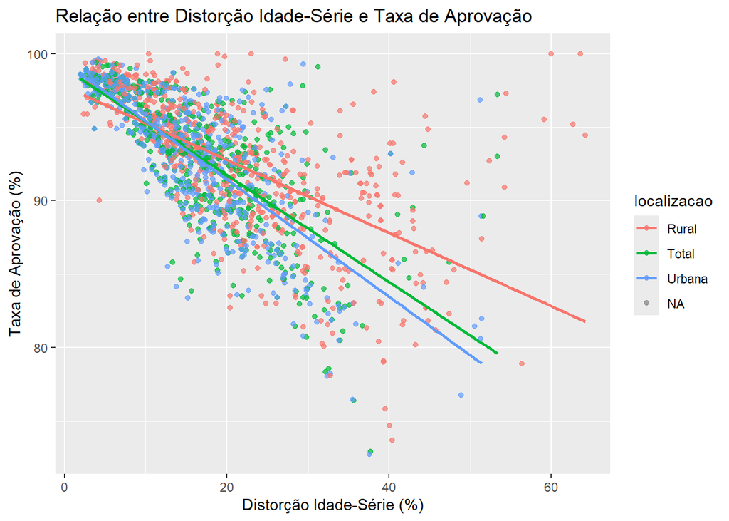

```r
library(ggplot2)

ggplot(base_final, aes(x = distorcao_total, y = aprovacao_total, color = localizacao)) +
  geom_point(alpha = 0.7) +
  geom_smooth(method = "lm", se = FALSE) +
  labs(
    title = "Relação entre Distorção Idade-Série e Taxa de Aprovação",
    x = "Distorção Idade-Série (%)",
    y = "Taxa de Aprovação (%)"
  )
```

O gráfico evidencia uma tendência decrescente: unidades com maior distorção idade-série apresentam sistematicamente menores taxas de aprovação. A linha de regressão confirma essa relação negativa.

### Abandono vs Aprovação

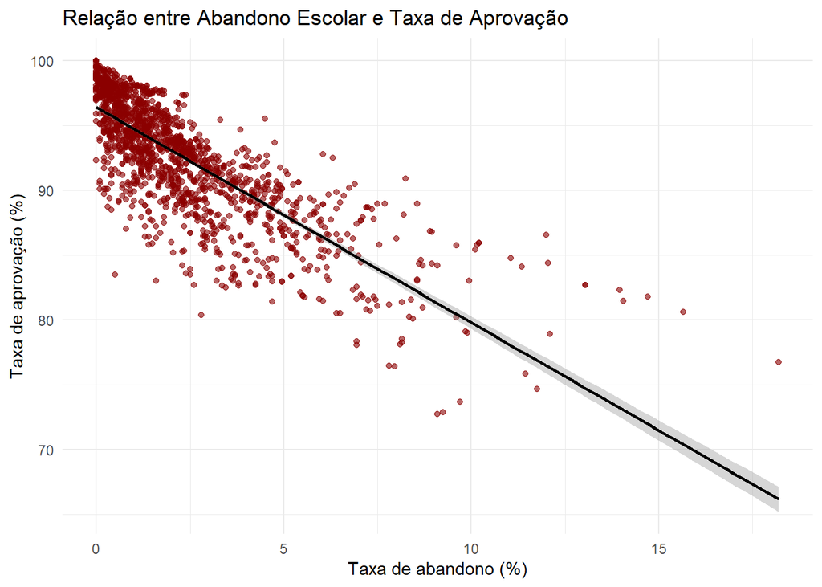

```r
ggplot(base_final, aes(x = abandono_total, y = aprovacao_total)) +
  geom_point(alpha = 0.6, color = "darkred") +
  geom_smooth(method = "lm", color = "black") +
  labs(
    title = "Relação entre Abandono Escolar e Taxa de Aprovação",
    x = "Taxa de abandono (%)",
    y = "Taxa de aprovação (%)"
  ) +
  theme_minimal()
```

Há uma clara queda na aprovação conforme o abandono escolar cresce. A dispersão mostra que mesmo pequenos aumentos no abandono estão associados a reduções perceptíveis na aprovação.

### Distorção vs Abandono

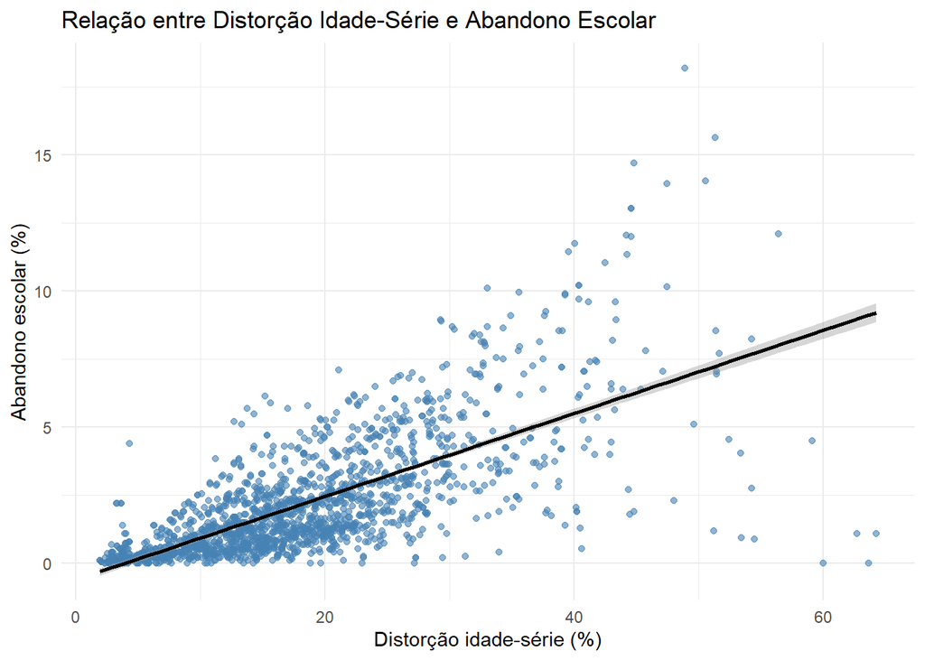

```r
ggplot(base_final, aes(x = distorcao_total, y = abandono_total)) +
  geom_point(alpha = 0.6, color = "steelblue") +
  geom_smooth(method = "lm", color = "black") +
  labs(
    title = "Relação entre Distorção Idade-Série e Abandono Escolar",
    x = "Distorção idade-série (%)",
    y = "Abandono escolar (%)"
  ) +
  theme_minimal()
```

A relação positiva indica que escolas e redes com maior distorção idade-série também tendem a apresentar maior abandono. Isso reforça a ideia de que atraso escolar e desistência fazem parte de um mesmo ciclo de exclusão.

## Conclusão

Do ponto de vista educacional, os resultados indicam que o fracasso escolar não se distribui de forma isolada: ele se acumula e se amplifica ao longo do tempo. Estudantes com atraso escolar enfrentam maiores barreiras de aprendizagem, maior probabilidade de reprovação e, como consequência, maior risco de abandono. Esses fatores reduzem diretamente a taxa de aprovação, criando um ciclo prolongado de exclusão educacional — especialmente em contextos mais vulneráveis. Assim, os achados reforçam a necessidade de políticas públicas voltadas à correção de fluxo, monitoramento preventivo do abandono, recuperação de aprendizagem, e intervenções direcionadas a grupos específicos (como redes rurais e estaduais).

Em síntese, entender essas relações não apenas esclarece o funcionamento dos indicadores educacionais, mas também contribui para a construção de um diagnóstico sólido que pode orientar gestores, escolas e pesquisadores na formulação de ações eficazes para melhorar o desempenho e promover maior equidade no sistema educacional brasileiro.